# INFO on Universities in the United States

Hanjiang Xu, Risa Nabari, Jett Chang-Lam

11/14/2022

## Project Dynamic

Using a compilation of data originating from a wide array of American colleges that was compiled by Samson Qian of MIT, we first arranged a table of specific data points by state, and locating the average values for each state’s average undergraduate population, admission rate, SAT submission rate, and cost of both out-of-state and in-state attendance. The data averages vary wildly from state to state with Nevada having a significantly higher average undergraduate population than other states such as Alaska. Similarly, Wyoming also eclipses Alaska in average admittance rate by double digit percentage points. Both of these could be due to the relatively low populations and amount of colleges located in these states.

### Summary information

Following are summary information we calculated in the summary information about our data set.

[output not shown]

```
## $num_observations
## [1] 51
##
## $highest_average_undergraduate
## [1] "Nevada"
##
## $highest_admit_rate
## [1] "Wyoming"
##
## $SAT_rate
## [1] "Delaware"
##
## $in_state_expense
## [1] "District of Columbia"
##
## $out_state_expense
## [1] "District of Columbia"
```

## Table

In the following summary table, we included information regarding universities such as average undergraduate enrollment, average admit rate, and average SAT submission rate of each state across the United States. The table is organized in descending order based on the average undergraduate enrollment, and it will only show the first ten states for this report.

Basic informaion of Universities of the first ten states based on enrollment

| State | Average Undergraduate Enrollment | Average Admit Rate (%) | Average SAT submit rate (%) |
| --- | --- | --- | --- |
| Nevada | 19396 | 84.50 | 79.50 |
| Utah | 17191 | 72.00 | 21.80 |
| Arizona | 16012 | 76.83 | 63.83 |
| New Mexico | 10151 | 63.50 | 23.25 |
| Wyoming | 10117 | 96.00 | 16.00 |
| Florida | 9525 | 54.86 | 60.71 |
| California | 9511 | 54.12 | 86.45 |
| Idaho | 8845 | 82.83 | 65.17 |
| Texas | 8635 | 64.25 | 66.80 |
| Colorado | 8471 | 72.71 | 26.79 |

## Charts

Following are the three charts we computed for our project:

### Chart #1: Average living expense (for out-of-state students)

The purpose of chart 1 is to present the average expense for the out of state students in each state. This gives the students insights to how expensive it may cost to attend and live in each state, which could give an idea to the students if they would like to apply the college/university based on their own economic status.

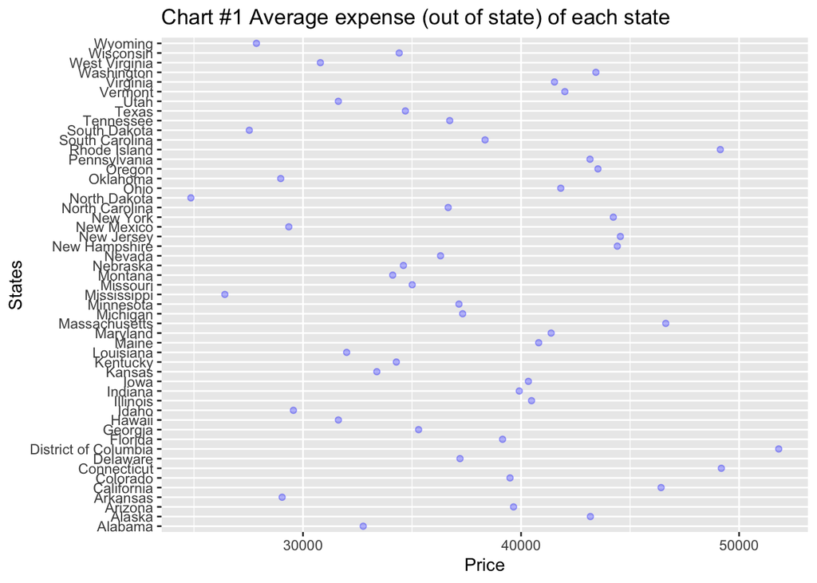

### Chart #2: Average university SAT submit rate of each state

Chart 2 contains information regarding the SAT submission rate of each state. We believe it is important for students to know whether SAT scores are important to schools in their desired region of studying. As the graph displays, Wisconsin and South Dakota have a rather low rate of SAT submission compare with states such as California and New York. In this case, students who intend to study California/New York would put more effort into SAT testings.

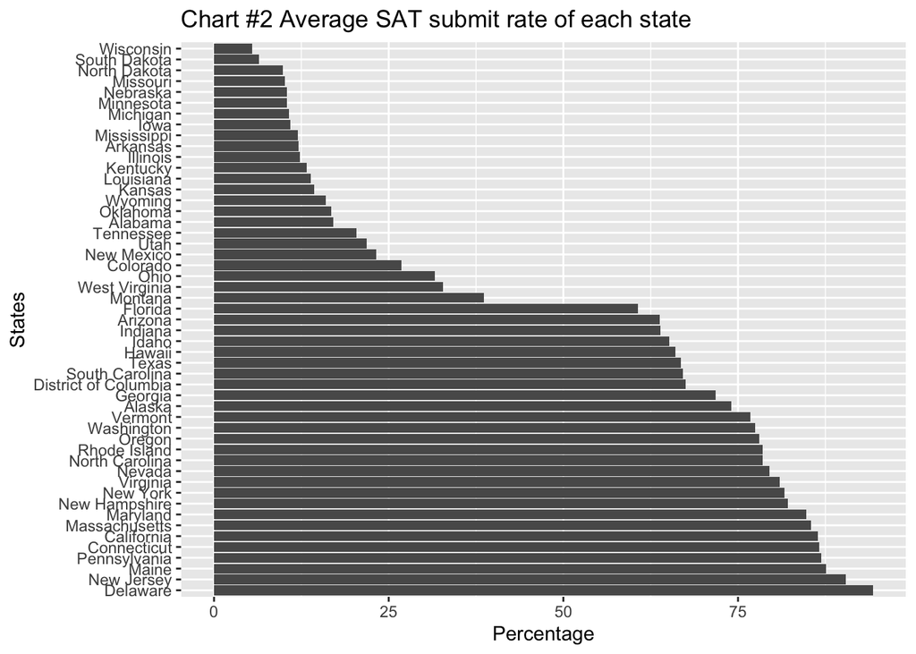

### Chart #3: Average university admission rate of each state

Chart 3 contains information regarding average admission rate of each state. To potential college students, admission rate is a crucial value to take into consideration since it is directly associated with the students’ future. It would be a unwise choice if students aim for colleges that have low admission rate. In the following graph, we can see that Wyoming universities have a surprisingly high admission rate. While comparing with the Chart 2, we can see that Wyoming also have a rather low SAT submission rate. The same phenomenon also apply to states like Wisconsin and South Dakota. In this case, we might be able to draw a correlation relationship between SAT submission rate and admission rate.

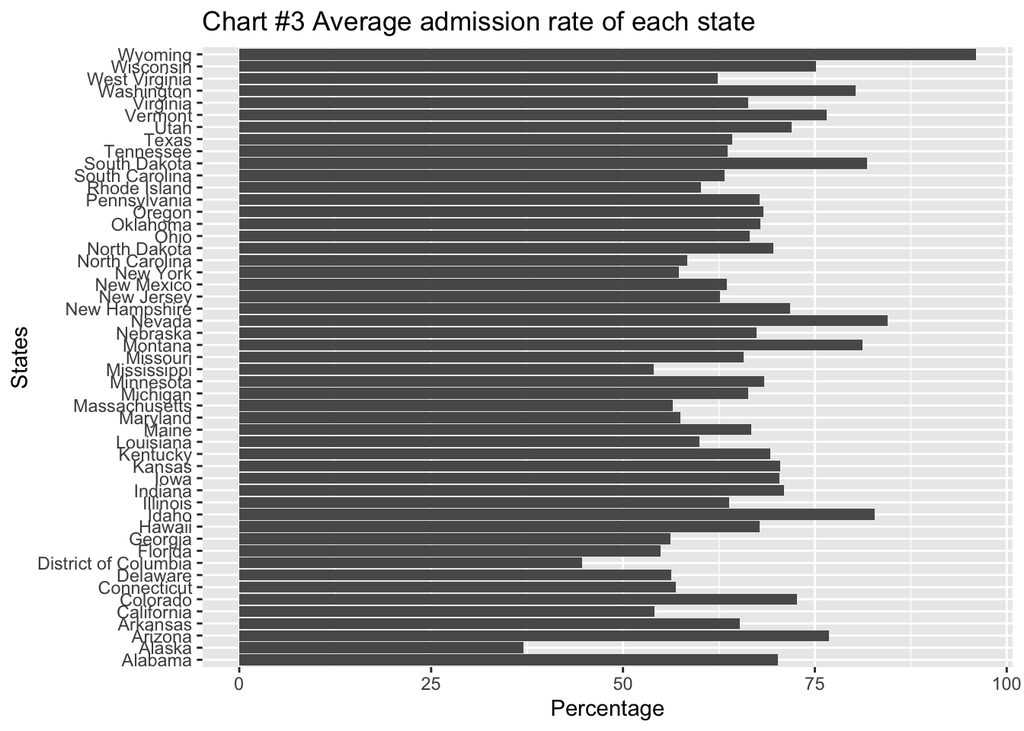